# Lab7

Evan Blosser

Tuesday, July 25, 2023

class note:

Incorporate a DATA folder made indirectly

```r
# create data folder and compres data
# usethis::use_data()
```

# Task 1

```r
getwd()
```

```
## [1] "C:/Users/galac/Documents/MATH4753EvanB/LAB7"
```

# Task 2

## mycchisim()

```r
mychisim<-function(n1=10,sigma1=3,mean1=5,iter=1000,ymax=0.1,...){
  # Generate the "iter" amount of samples using rnorm
  y1=rnorm(n1*iter,mean=mean1,sd=sigma1)
  # Define dimension of data matrix by user input
  data1.mat=matrix(y1,nrow=n1,ncol=iter,byrow=TRUE)
  # Define ssq1
  ssq1=apply(data1.mat,2,var)
  # chi-sqaure Statistic
  #  denoted as 'w'
  w=(n1-1)*ssq1/sigma1^2
  # Histogram
  #   - User Input Adaptive labels
  hist(w,freq=FALSE, ylim=c(0,ymax),
       main=substitute(paste("Sample size = ",n[1]," = ",n1," statistic = ",chi^2)),
       xlab=expression(paste(chi^2, "Statistic",sep=" ")), las=1)
  # Creates density plot lines on-top of histogram
  lines(density(w),col="Blue",lwd=3)
   # Creates theoretical curve on-top of histogram
  curve(dchisq(x,n1-1),add=TRUE,col="Red",lty=2,lwd=3)
  # Adaptive Title:
  # mathematical annotation -see ?plotmath
  title=expression(chi^2==frac((n[1]-1)*s^2,sigma^2))
  # Legend placed using locater/coordinates if in .rmd
  legend("topright",c("Simulated","Theoretical"),col=c("Blue","Red"),lwd=4,lty=1:2,bty="n",title=title)
  ### Function Return ###
  return(list(w=w,summary=summary(w),sd=sd(w),fun="Chi-sq"))
}
```

## Plot: 1/4

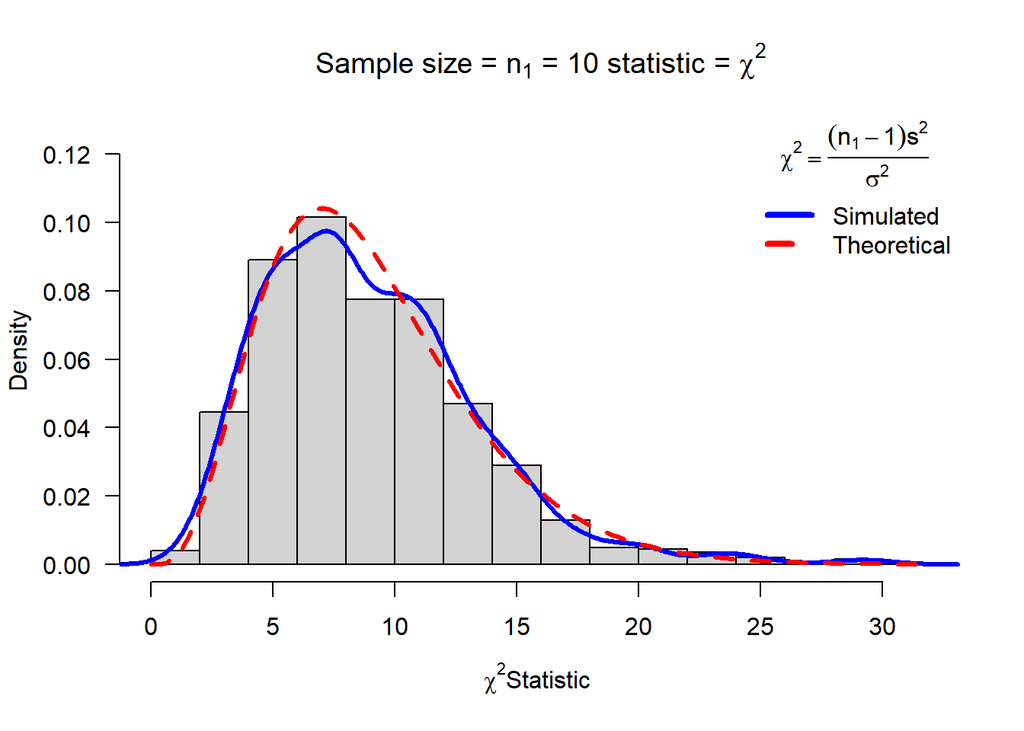

[output not shown]

[output cut: 139 more lines]

```r
mychisim(n1 = 10, iter=1000,mean1 = 10,sigma1 = 4,ymax=0.125)
```

## Plot: 2/4

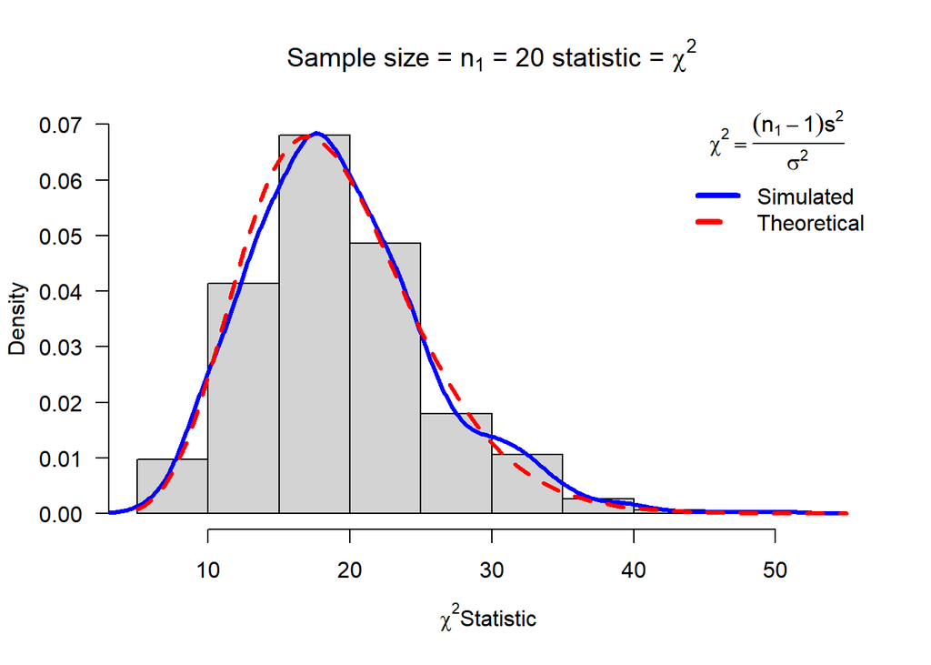

[output not shown]

[output cut: 139 more lines]

```r
mychisim(n1 = 20, iter=1000,mean1 = 10,sigma1 = 4,ymax=0.07)
```

## Plot: 3/4

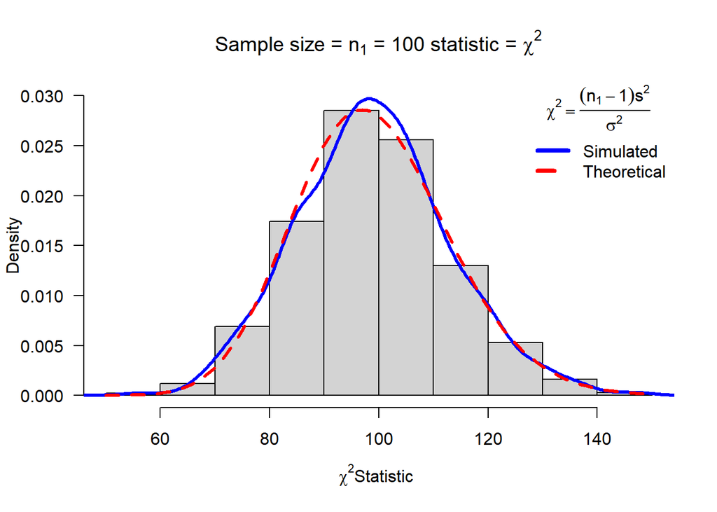

[output not shown]

[output cut: 139 more lines]

```r
mychisim(n1 = 100, iter=1000,mean1 = 10,sigma1 = 4,ymax=0.03)
```

## Plot: 4/4

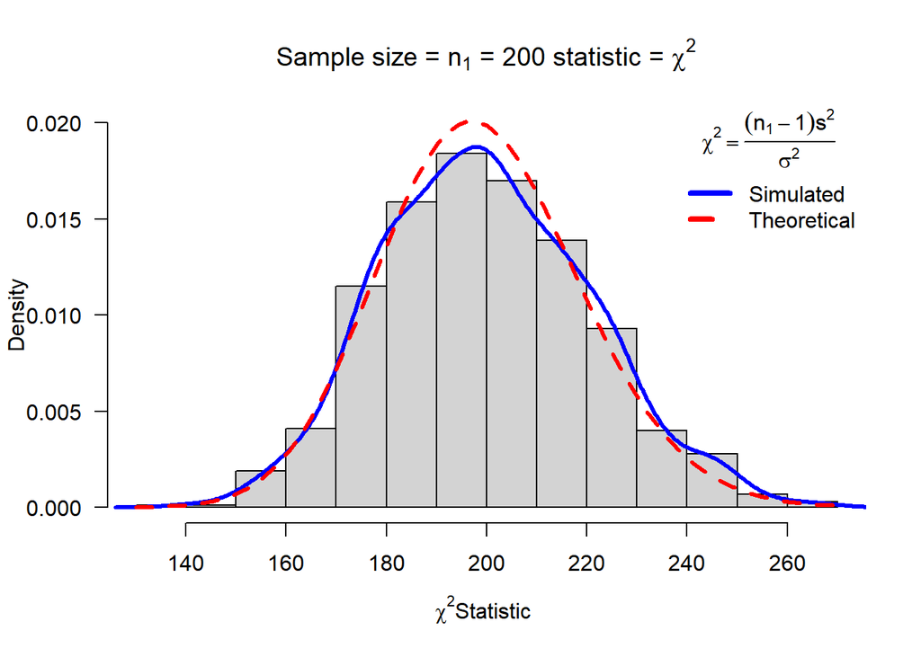

[output not shown]

[output cut: 121 more lines]

```r
mychisim(n1 = 200, iter=1000,mean1 = 10,sigma1 = 4,ymax=0.02)
```

## Histogram: chisq$w

```r
chisq=mychisim(n1 = 10, iter=1500,mean1 = 20,sigma1 = 10,ymax=0.15)
```

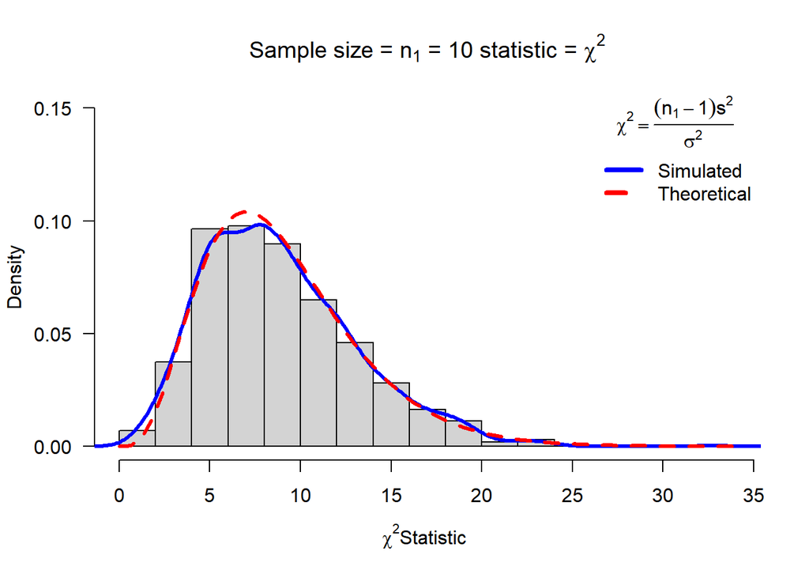

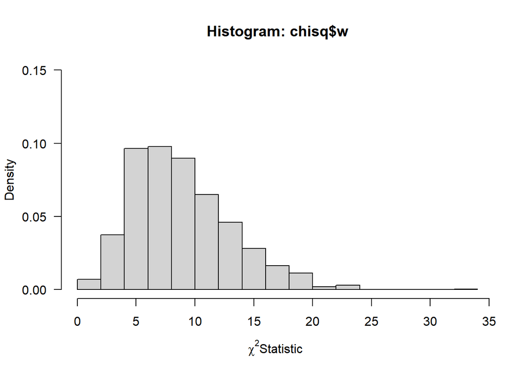

```r
 hist(chisq$w,freq=FALSE, ylim=c(0,.15),
       main="Histogram: chisq$w",
       xlab=expression(paste(chi^2, "Statistic",sep=" ")), las=1)
```

# Task 3

## Part A

### myTsim()

```r
myTsim<-function(n1=10,sigma1=3,mean1=5,iter=1000,ymax=0.1,x=2,y=0.3,...){    # adjust ymax to make graph fit
y1=rnorm(n1*iter,mean=mean1,sd=sigma1)# generate iter samples of size n1

data1.mat=matrix(y1,nrow=n1,ncol=iter,byrow=TRUE) # Each column is a sample size n1

sd1=apply(data1.mat,2,sd) # sd
ybar=apply(data1.mat,2,mean)  # mean

w=(ybar-mean1)/(sd1/sqrt(n1))      #T stat

hist(w,freq=FALSE, ylim=c(0,ymax), # Histogram with annotation
main=substitute(paste("Sample size = ",n[1]," = ",n1," statistic = ",T," iterations= ",iter)),
xlab=expression(paste(T, "Statistic",sep=" ")), las=1)
lines(density(w),col="Blue",lwd=3) # add a density plot
curve(dt(x,n1-1),add=TRUE,col="Red",lty=2,lwd=3) # add a theoretical curve
title=expression(T==frac((bar(y)-mu),s/sqrt(n1))) #mathematical annotation -see ?plotmath
### Change legend location to "topright"
legend("topright",c("Simulated","Theoretical"),col=c("Blue","Red"),lwd=4,lty=1:2,bty="n",title=title) # Legend #
invisible(list(w=w,summary=summary(w),sd=sd(w),fun="T")) # some output to use if needed
}
```

### Plot: 1/4

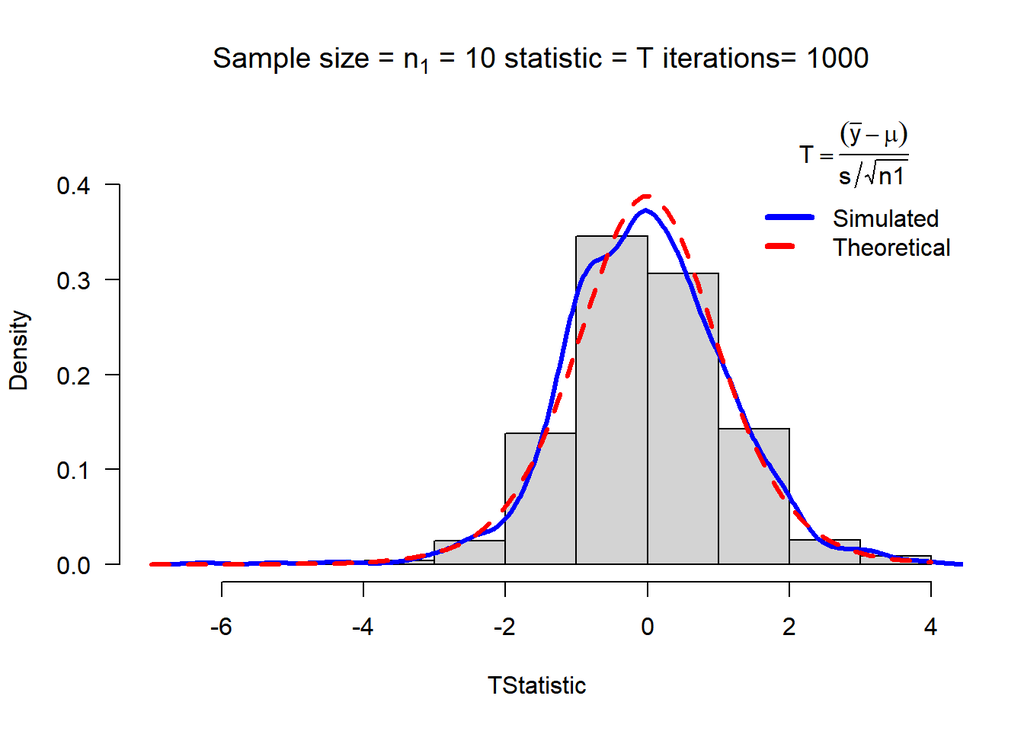

```r
myTsim(n1 = 10,iter = 1000,mean1 = 10,sigma1 = 4,ymax=0.45)
```

### Plot: 2/4

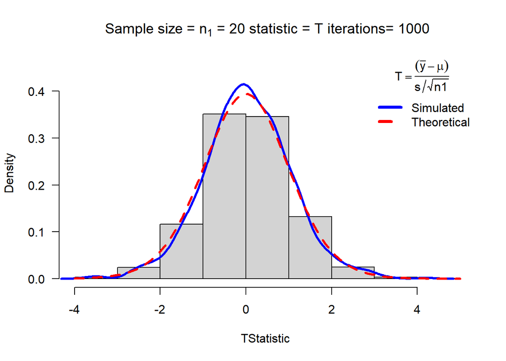

```r
myTsim(n1 = 20,iter = 1000,mean1 = 10,sigma1 = 4,ymax=0.45)
```

### Plot: 3/4

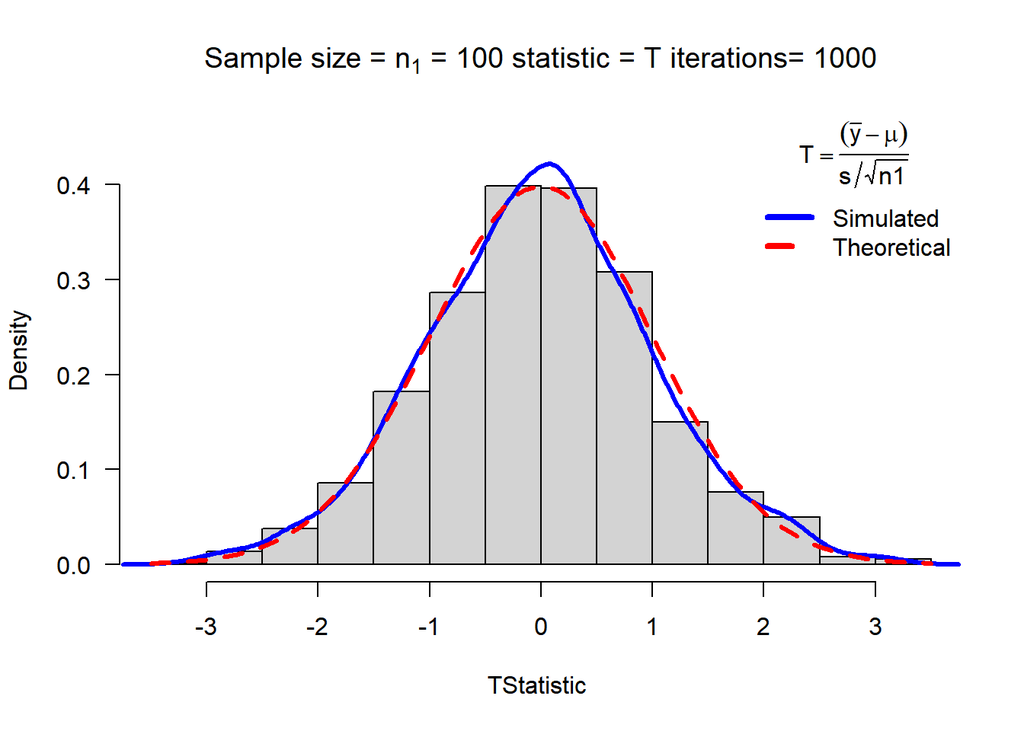

```r
myTsim(n1 = 100,iter = 1000,mean1 = 10,sigma1 = 4,ymax=0.45)
```

### Plot: 4/4

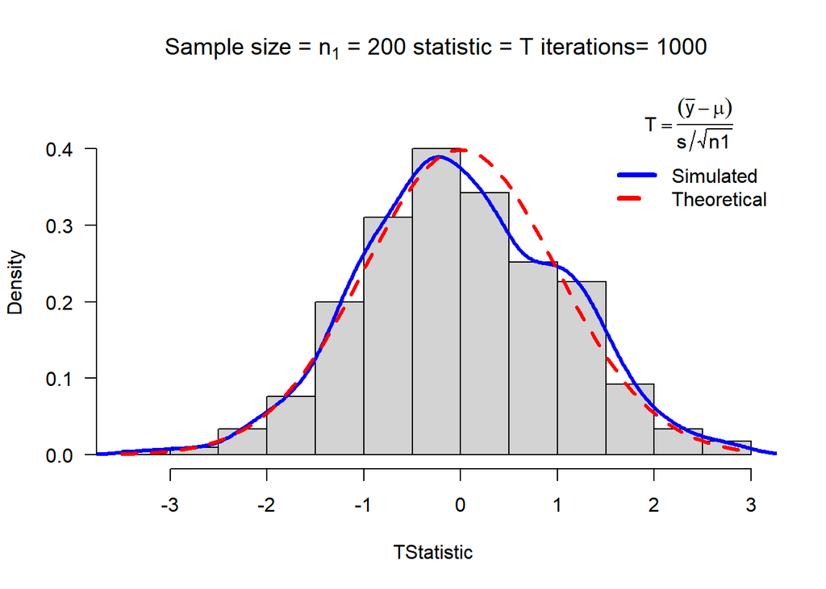

```r
myTsim(n1 = 200,iter = 1000,mean1 = 10,sigma1 = 4,ymax=0.45)
```

## Part B

```r
T <- myTsim(n1 = 10,iter = 1500,mean1 = 20,sigma1 = 10,ymax=0.45)
```

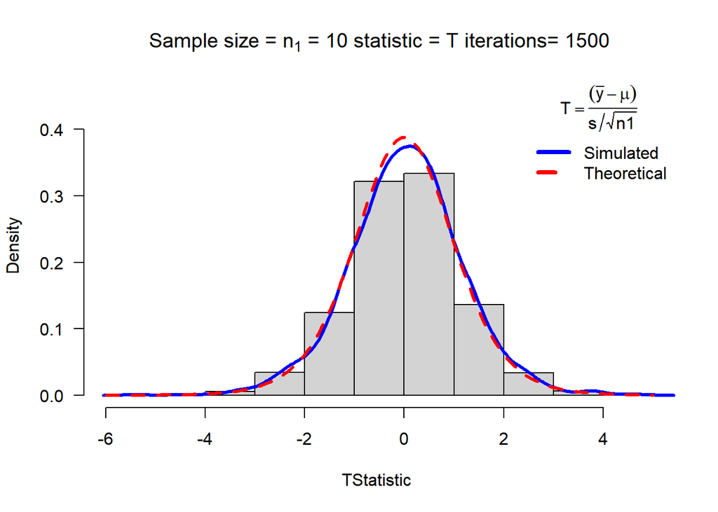

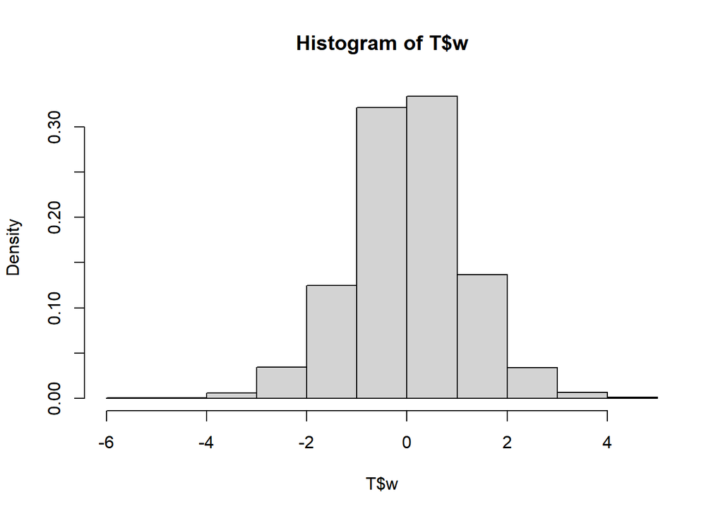

```r
hist(T$w, freq=FALSE)
```

# Task 4

## mychisim2()

```r
mychisim2<-function(n1=10,n2=14,sigma1=3,sigma2=3,mean1=5,mean2=10,iter=1000,ymax=0.07,...){
  # Generate the 1st set of "iter" amount of samples using rnorm
  y1=rnorm(n1*iter,mean=mean1,sd=sigma1)
  # Generate the 2nd set of "iter" amount of samples using rnorm
  y2=rnorm(n2*iter,mean=mean2,sd=sigma2)
  # Define dimension of data matrix by user input
  data1.mat=matrix(y1,nrow=n1,ncol=iter,byrow=TRUE)
  data2.mat=matrix(y2,nrow=n2,ncol=iter,byrow=TRUE)
  # Define 'S' Squared
  ssq1=apply(data1.mat,2,var)
  ssq2=apply(data2.mat,2,var)
  # pooled s squared 'ssq1' & 'ssq2'
  spsq=((n1-1)*ssq1 + (n2-1)*ssq2)/(n1+n2-2)
  # chi-sqaure Statistic
  #  denoted as 'w'
  #  -sigma1=sigma2
  w=(n1+n2-2)*spsq/(sigma1^2)
  # Histogram
  #   - User Input Adaptive labels
  hist(w,freq=FALSE, ylim=c(0,ymax),
       main=substitute(paste("Sample size = ",n[1]+n[2]," = ",n1+n2," statistic = ",chi^2)),
       xlab=expression(paste(chi^2, "Statistic",sep=" ")), las=1)
  # Creates density plot lines on-top of histogram
  lines(density(w),col="Blue",lwd=3)
  # Creates theoretical curve on-top of histogram
  curve(dchisq(x,n1+n2-2),add=TRUE,col="Red",lty=2,lwd=3)
  # Adaptive Title:
  # mathematical annotation -see ?plotmath
  title=expression(chi^2==frac((n[1]+n[2]-2)*S[p]^2,sigma^2))
  # Legend placed using locater/coordinates if in .rmd
  legend("topright",c("Simulated","Theoretical"),col=c("Blue","Red"),lwd=4,lty=1:2,bty="n",title=title)
  ### Function Return ###
  return(list(w=w,summary=summary(w),sd=sd(w),fun="Chi-sq"))
}
```

## Plot: 1/4

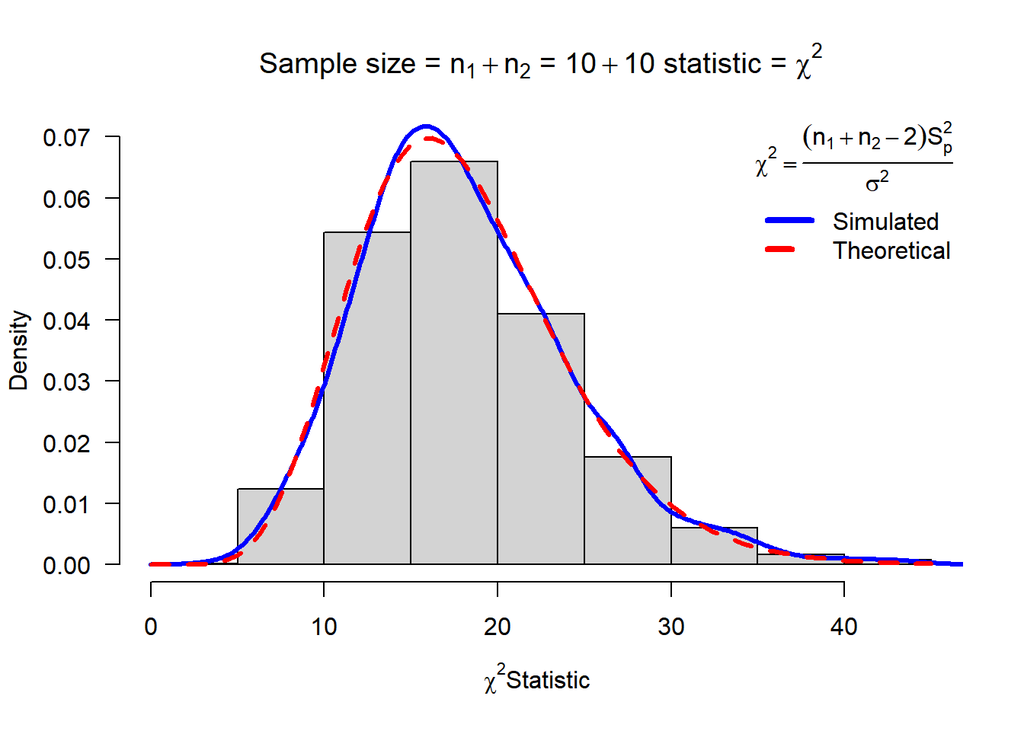

[output not shown]

[output cut: 139 more lines]

```r
mychisim2(n1 = 10,n2 = 10,mean1 = 5,mean2 = 10,sigma1 = 4,sigma2 = 4,iter=1000)
```

## Plot: 2/4

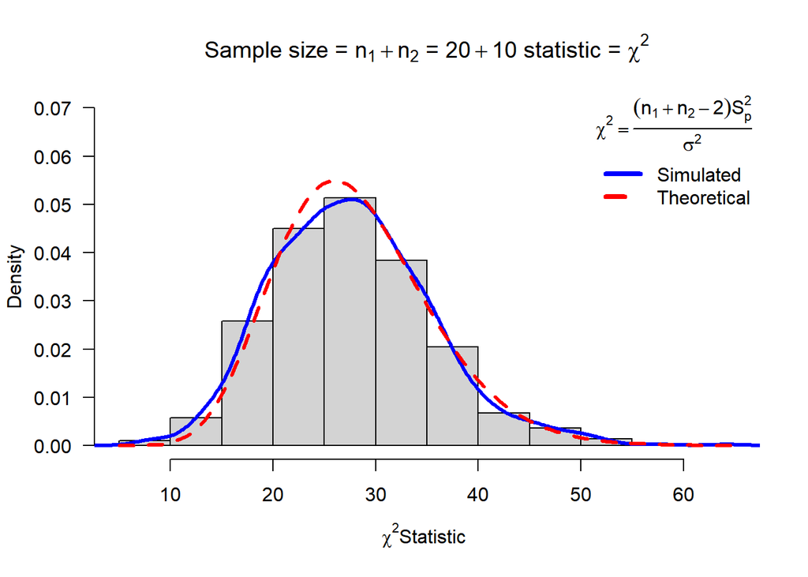

[output not shown]

[output cut: 139 more lines]

```r
mychisim2(n1 = 20,n2 = 10,mean1 = 3,mean2 = 5,sigma1 = 10,sigma2 = 10,iter=1000)
```

## Plot: 3/4

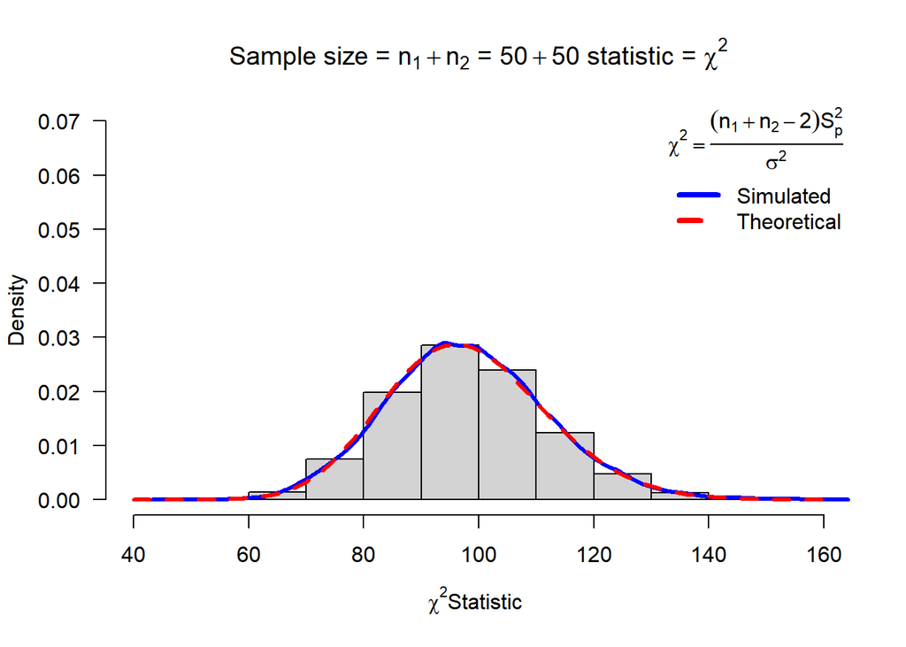

[output not shown]

[output cut: 1425 more lines]

```r
mychisim2(n1 = 50,n2 = 50,mean1 = 5,mean2 = 10,sigma1 = 4,sigma2 = 4,iter=10000)
```

## Plot: 4/4

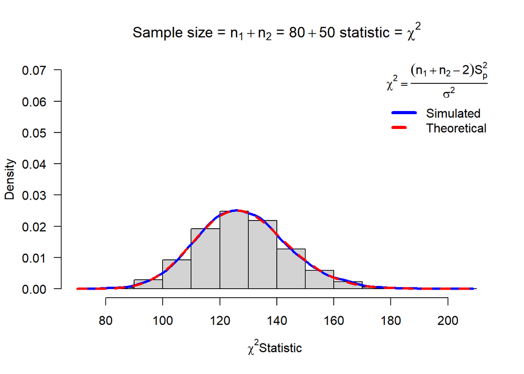

[output not shown]

[output cut: 1425 more lines]

```r
mychisim2(n1 = 80,n2 = 50,mean1 = 3,mean2 = 5,sigma1 = 10,sigma2 = 10,iter=10000)
```

## Default Values

```r
chisim2=mychisim2(iter=10000)
```

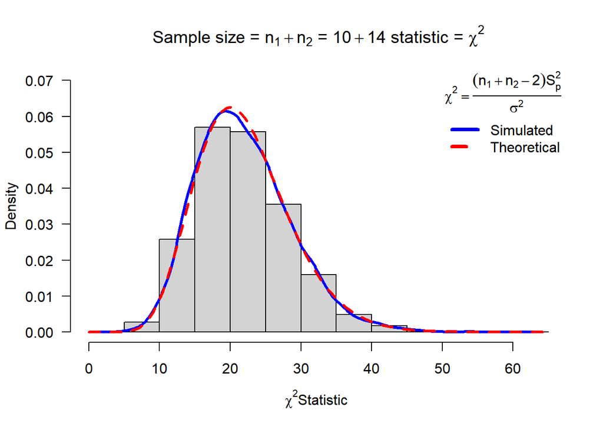

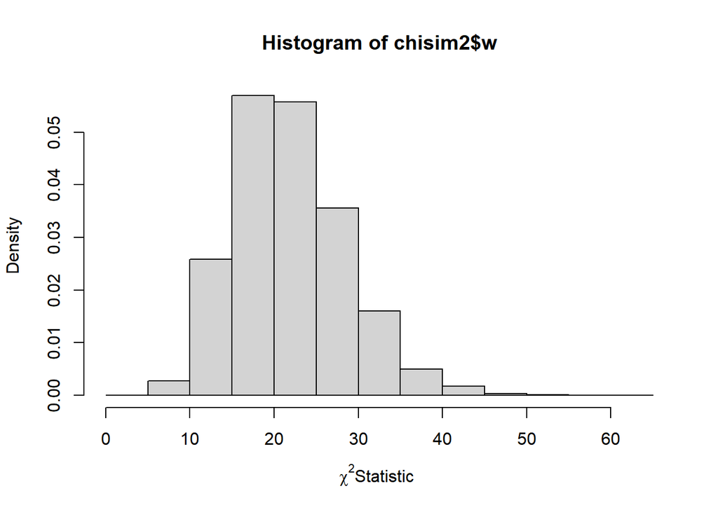

```r
hist(chisim2$w, freq=FALSE,xlab=expression(paste(chi^2, "Statistic",sep=" ")))
```

# Task 5

## T Statistic

The following equation is the student’s T statistic calculated by the function:
$$\begin{align*}
T =
\frac{(\bar{Y_1}-\bar{Y_2})-(\mu_1-\mu_2)}{S_p\sqrt{\frac{1}{n_1}+\frac{1}{n_2}}}
\end{align*}$$
The notations in the book specify that the student’s T statistic has $\nu = (n_1+n_2-2)$ Degrees of Freedom. Also, the variance for both samples $n_1$ & $n_2$ are assumed to be equal or $\sigma_1^2=\sigma_2^2=\sigma^2$. The **Definition 6.15** states the mean and standard deviation of the sampling distribution $\mu_{\bar{Y}}=\mu$ & $\sigma_{\bar{Y}} = \frac{\sigma}{\sqrt(n)}$. **Theorem 6.10** states the linear combinations and their relation to the Expectation and Variance, while **Theorem 6.11** defines the chi-square density function.

## myTsim2()

```r
myTsim2<-function(n1=10,n2=14,sigma1=3,sigma2=3,mean1=5,mean2=10,iter=1000,ymax=0.5,...){
  # Generate the 1st set of "iter" amount of samples using rnorm
  y1=rnorm(n1*iter,mean=mean1,sd=sigma1)
  # Generate the 2nd set of "iter" amount of samples using rnorm
  y2=rnorm(n2*iter,mean=mean2,sd=sigma2)
  # Define dimension of data matrix by user input
  data1.mat=matrix(y1,nrow=n1,ncol=iter,byrow=TRUE)
  data2.mat=matrix(y2,nrow=n2,ncol=iter,byrow=TRUE)
  # Define 'S' Squared & ybar as mean
  ssq1=apply(data1.mat,2,var)
  ybar1= apply(data1.mat,2,mean)
  ssq2=apply(data2.mat,2,var)
  ybar2=apply(data2.mat,2,mean)
  # pooled s squared 'ssq1' & 'ssq2'
  spsq=((n1-1)*ssq1 + (n2-1)*ssq2)/(n1+n2-2)
  # chi-sqaure Statistic
  #  denoted as 'w'
  #  -sigma1=sigma2
  #  - ybar differenced with mean
  w=((ybar1-ybar2)-(mean1-mean2))/sqrt(spsq*(1/n1+1/n2))
  # Histogram
  #   - User Input Adaptive labels
  hist(w,freq=FALSE, ylim=c(0,ymax),
       main=substitute(paste("Sample size = ",n[1]+n[2]," = ",n1+n2," statistic = ",T)),
       xlab=paste(" T Statistic",sep=""), las=1)
  # Creates density plot lines on-top of histogram
  lines(density(w),col="Blue",lwd=3)
  # Creates theoretical curve on-top of histogram
  curve(dt(x,n1+n2-2),add=TRUE,col="Red",lty=2,lwd=3)
  # Adaptive Title:
  # mathematical annotation -see ?plotmath
  title=expression(T==frac((bar(Y)[1]-bar(Y)[2])-(mu[1]-mu[2]),S[p]*sqrt(frac(1,n[1])+frac(1,n[2]))))
  # Legend placed using locater/coordinates if in .rmd
  ### Chanted to locator(1) in mylab.R
  ### use "topright" location for .rmd doc
  legend("topright",c("Simulated","Theoretical"),col=c("Blue","Red"),lwd=4,lty=1:2,bty="n",title=title)
  ### Function Return ###
  return(list(w=w,summary=summary(w),sdw=sd(w),fun="T"))
}
```

## Plot: 1/4

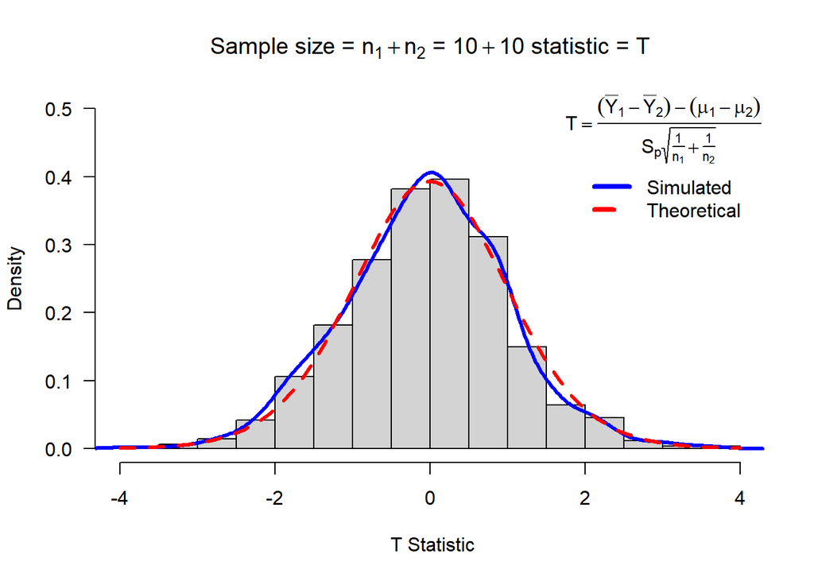

[output not shown]

[output cut: 196 more lines]

```r
myTsim2(n1=10,n2=10,mean1=5,mean2=10,sigma1=4,sigma2=4,iter=1000,ymax=0.5)
```

## Plot: 2/4

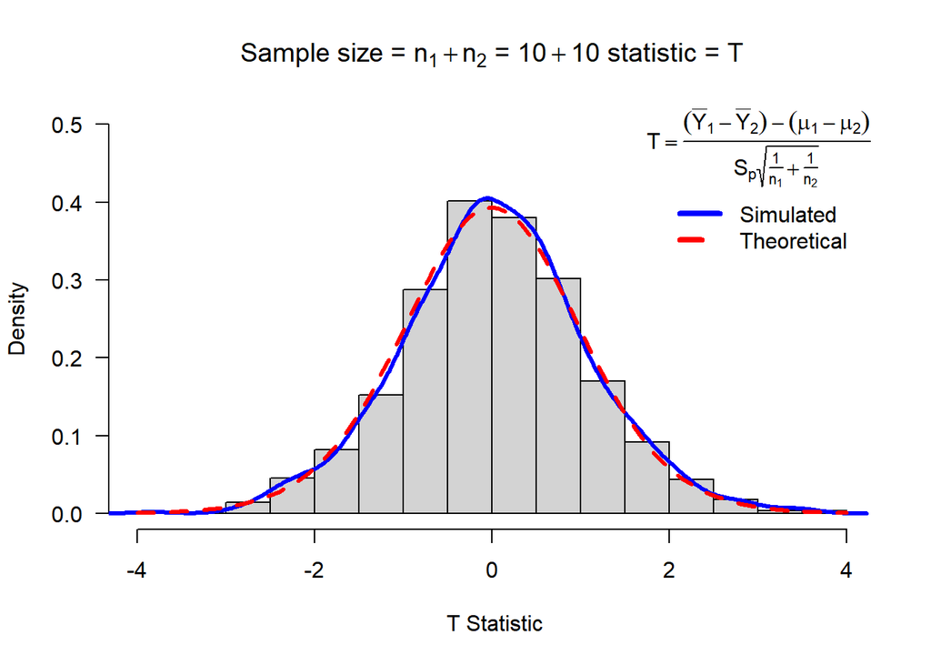

[output not shown]

[output cut: 196 more lines]

```r
myTsim2(n1=10,n2=10,mean1=5,mean2=10,sigma1=4,sigma2=4,iter=1000,ymax=0.5)
```

## Plot: 3/4

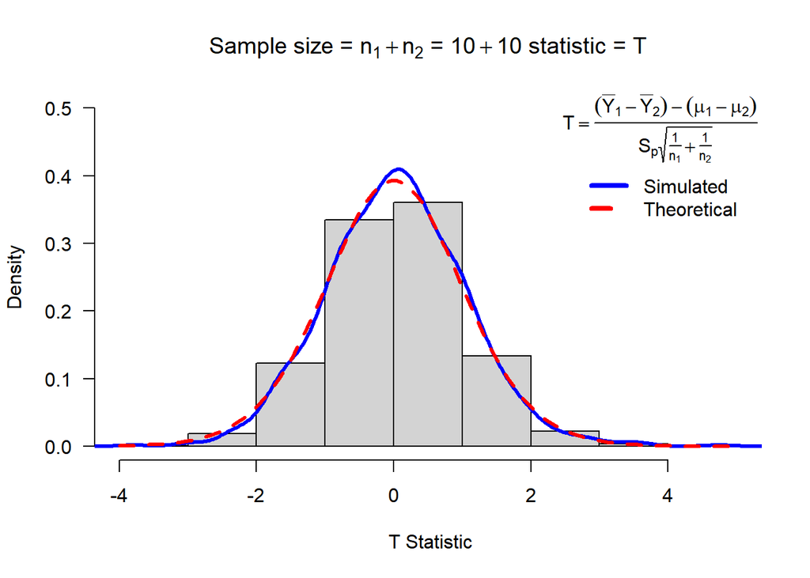

[output not shown]

[output cut: 196 more lines]

```r
myTsim2(n1=10,n2=10,mean1=5,mean2=10,sigma1=4,sigma2=4,iter=1000,ymax=0.5)
```

## Plot: 4/4

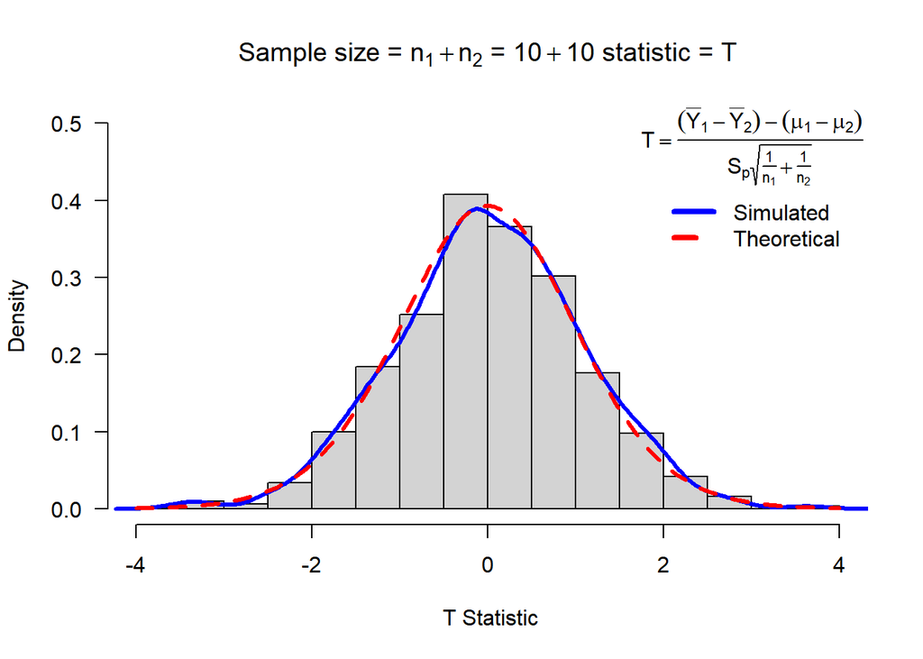

[output not shown]

[output cut: 196 more lines]

```r
myTsim2(n1=10,n2=10,mean1=5,mean2=10,sigma1=4,sigma2=4,iter=1000,ymax=0.5)
```

## Default Values

```r
T2 <- myTsim2(iter = 10000)
```

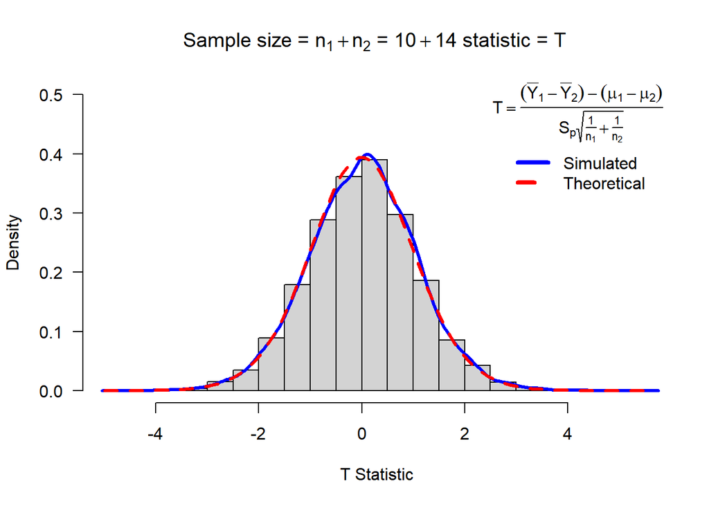

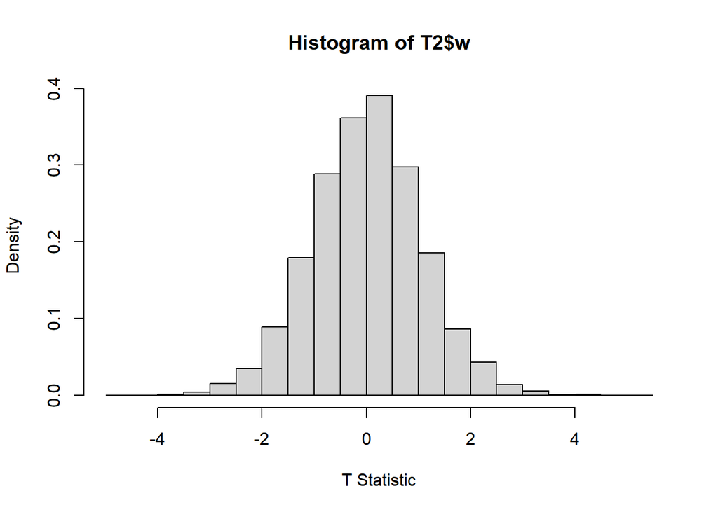

```r
hist(T2$w,freq=FALSE, xlab = "T Statistic")
```

# Task 6

## F Statistic

The function myFsim2() calculates the F statistic which is given as follows:
$$\begin{align*}
F= \frac{S_1^2}{S_2^2}\frac{\sigma_2^2}{\sigma_1^2}
\end{align*}$$
The notatoins ad that the that the numerator and denomenator Degrees of Freedom are $\nu_1 = (n_1-1)$ & $\nu_2 = (n_2-1)$, respectivly. There are **No Additional Assumptions**, and it was derived from **Theorem 6.11** and **Definition 6.27**.

## myFsim2()

```r
myFsim2<-function(n1=10,n2=14,sigma1=3,sigma2=2,mean1=5,mean2=10,iter=1000,ymax=0.9,...){
  # Generate the 1st set of "iter" amount of samples using rnorm
  y1=rnorm(n1*iter,mean=mean1,sd=sigma1)
  # Generate the 2nd set of "iter" amount of samples using rnorm
  y2=rnorm(n2*iter,mean=mean2,sd=sigma2)
  # Define dimension of data matrix by user input
  data1.mat=matrix(y1,nrow=n1,ncol=iter,byrow=TRUE)
  data2.mat=matrix(y2,nrow=n2,ncol=iter,byrow=TRUE)
  # Define 'S' Squared
  ssq1=apply(data1.mat,2,var)
  ssq2=apply(data2.mat,2,var)
  # chi-sqaure Statistic
  #  denoted as 'w'
  #  -sigma1=sigma2
  #  -spsq=((n1-1)*ssq1 + (n2-1)*ssq2)/(n1+n2-2) # pooled s squared
  w=ssq1*sigma2^2/(ssq2*sigma1^2)
  # Histogram
  #   - User Input Adaptive labels
  hist(w,freq=FALSE, ylim=c(0,ymax),
       main=substitute(paste("Sample size = ",n[1]+n[2]," = ",n1+n2," statistic = ",F)),
       xlab=paste("F Statistic",sep=""), las=1)
  # Creates density plot lines on-top of histogram
  lines(density(w),col="Blue",lwd=3)
  # Creates theoretical curve on-top of histogram
  curve(df(x,n1-1,n2-1),xlim=c(0,6),add=TRUE,col="Red",lty=2,lwd=3)
  # Adaptive Title:
  # mathematical annotation -see ?plotmath
  title=expression(F==frac(s[1]^2,s[2]^2)*frac(sigma[2]^2,sigma[1]^2))
  # Legend placed using locater/coordinates if in .rmd
  legend("topright",c("Simulated","Theoretical"),col=c("Blue","Red"),lwd=4,lty=1:2,bty="n",title=title)
  ### Function Return ###
  return(list(w=w,summary=summary(w),sd=sd(w),fun="F"))
}
```

## Plot: 1/4

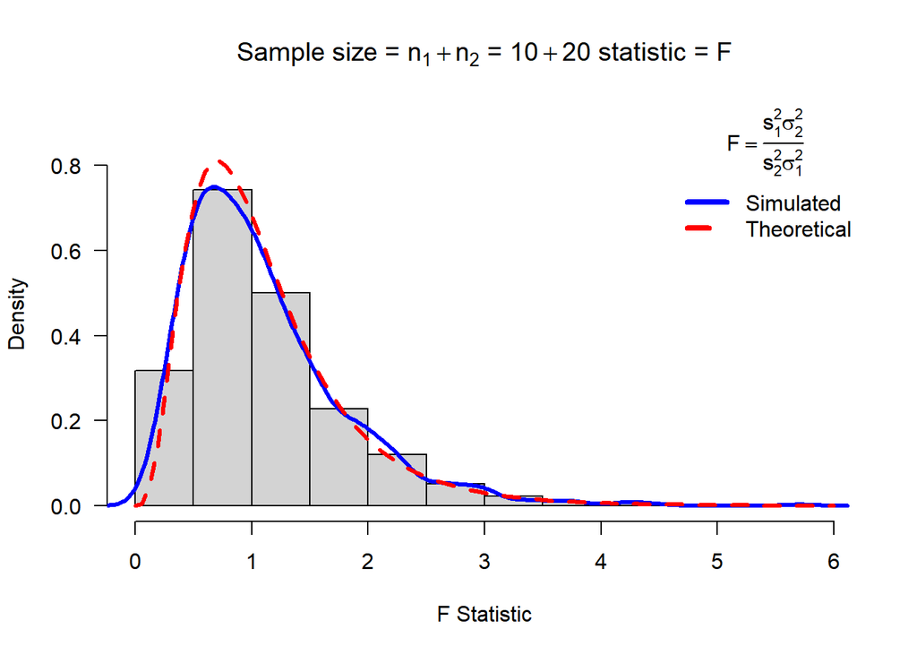

[output not shown]

[output cut: 139 more lines]

```r
myFsim2(n1=10,n2=20,mean1=5,mean2=7,sigma1=3.5,sigma2=.2,iter=1000,ymax=0.9)
```

## Plot: 2/4

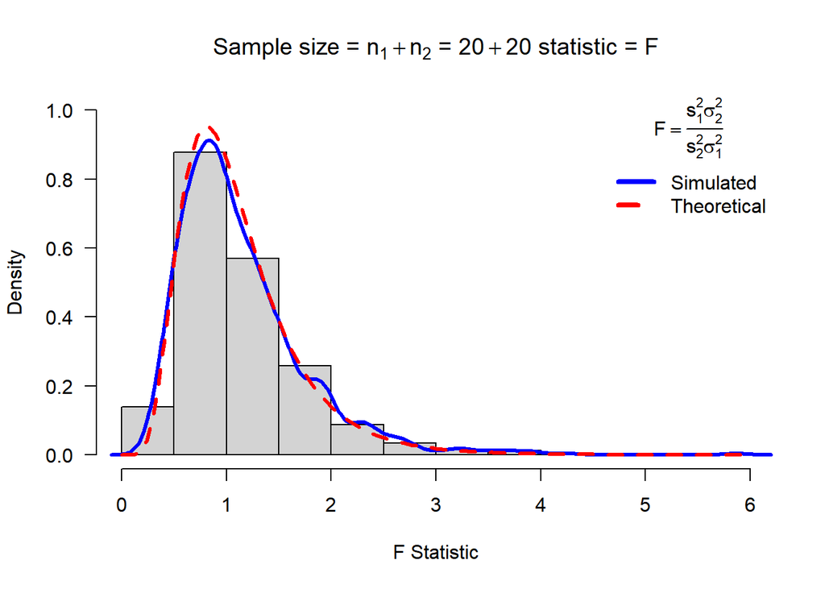

[output not shown]

[output cut: 139 more lines]

```r
myFsim2(n1=20,n2=20,mean1=10,mean2=10,sigma1=5,sigma2=1,iter=1000,ymax=1)
```

## Plot: 3/4

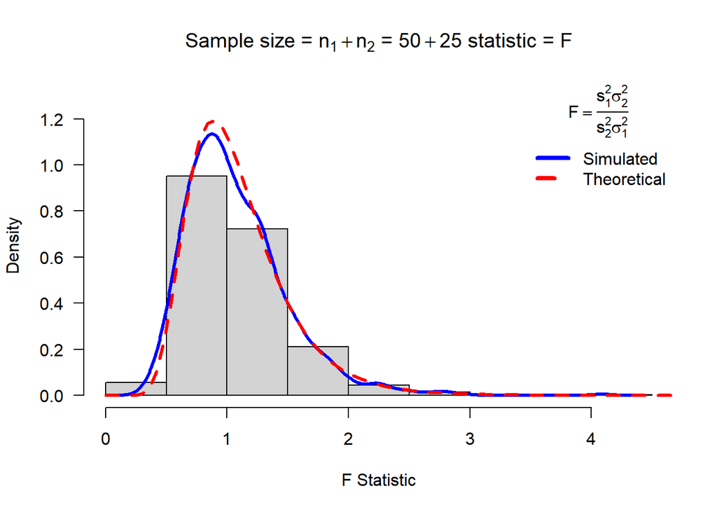

[output not shown]

[output cut: 139 more lines]

```r
myFsim2(n1=50,n2=25,mean1=7.5,mean2=11,sigma1=4,sigma2=4,iter=1000,ymax=1.3)
```

## Plot: 4/4

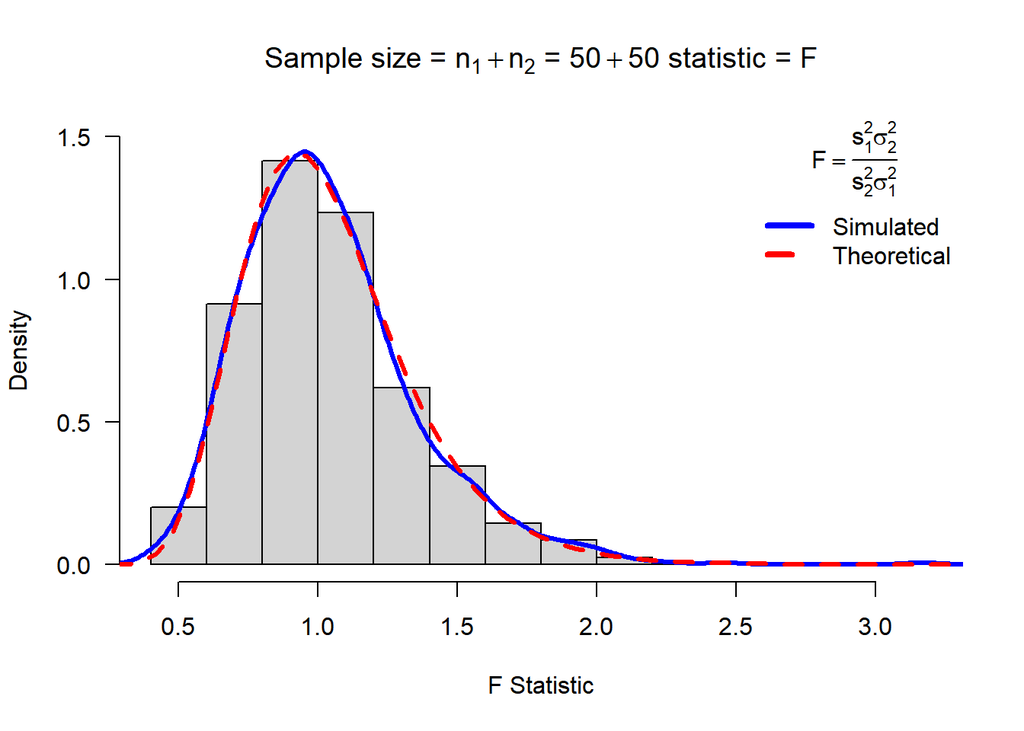

[output not shown]

[output cut: 139 more lines]

```r
myFsim2(n1=50,n2=50,mean1=7.5,mean2=11,sigma1=4,sigma2=4,iter=1000,ymax=1.5)
```

## Default Values

```r
F2=myFsim2(iter=10000)
```

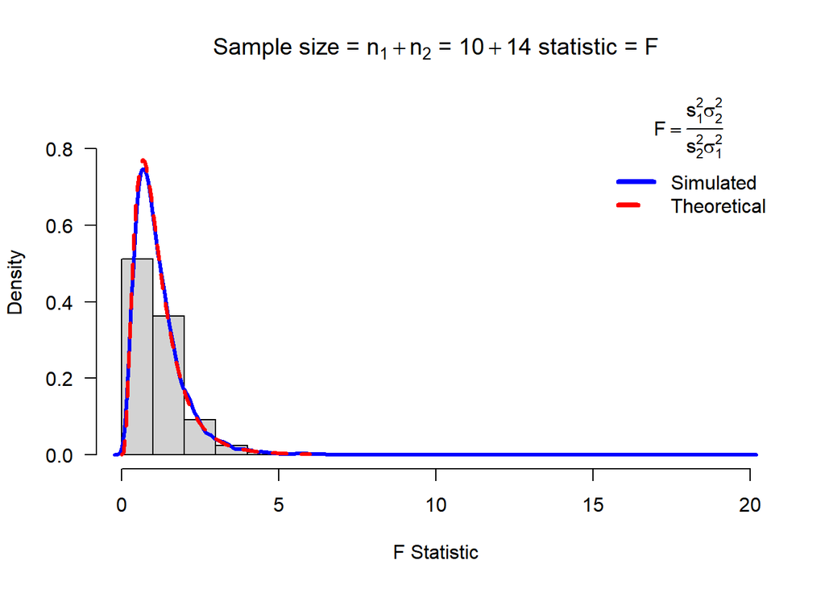

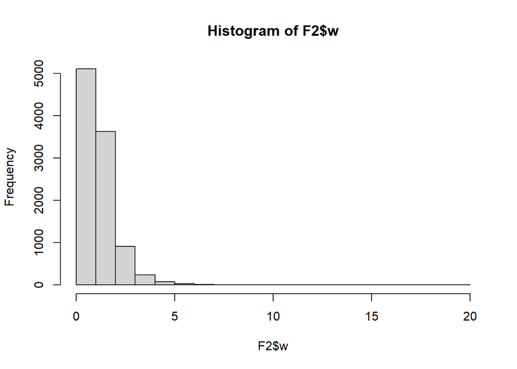

```r
hist(F2$w)
```

# Task 7

```r
fire=read.csv("FIREDAM.csv")
```

```r
library(MATH4753EvanB)
data("fire")
knitr::kable(head(fire))
```

| DISTANCE | DAMAGE |
| --- | --- |
| 3.4 | 26.2 |
| 1.8 | 17.8 |
| 4.6 | 31.3 |
| 2.3 | 23.1 |
| 3.1 | 27.5 |
| 5.5 | 36.0 |